# Ayudantía Muestras Complejas

Ayudantía N3

Autor/a

Francisca Hernández  
francisca.hernandez_c@mail.udp.cl

Fecha de publicación

domingo 05 de abril, 2026

[figure not shown]

**Análisis Avanzado de Datos II**  
Facultad de Ciencias Sociales e Historia

## ¿ Qué son las muestras complejas ?

Una muestra compleja es cuando **no eliges a las personas completamente al azar**, sino que usas un proceso en etapas o por grupos (por ejemplo, primero comunas, luego hogares y después personas). Esto se hace para que la **muestra represente mejor la realidad**, especialmente en estudios grandes, aunque implica que no todos tienen la misma probabilidad de ser seleccionados.

### ¿Por qué se utilizan?

Se hacen porque **permiten estudiar poblaciones grandes de forma más realista, ordenada y eficiente**. En la práctica, es muy difícil y caro seleccionar personas totalmente al azar en una investigación (MAS), por eso se agrupa la población (por comunas, hogares, etc.) y se selecciona por etapas. **Así se logra una muestra más representativa de la diversidad social, reduciendo costos y facilitando el trabajo de terreno**.

### ¿Qué debemos saber del muestreo aleatorio complejo?

Consta de estrategias:

- **Estratificación**

**¿Que es la estratificación?**

Dividir la población total en subgrupos homogéneos (estratos) antes de realizar el muestreo. Esta nos asegura representatividad, mejora la precisión y permite análisis por estratos.

- **Muestreo por Conglomerados**

**¿ Qué es el muestreo por conglomerados?**

El muestreo por conglomerados consiste en dividir la población en grupos (generalmente geográficos), seleccionar algunos al azar y luego encuestar a todos o a una parte de los individuos dentro de esos grupos.

Nos ayuda a reducir costos y logística

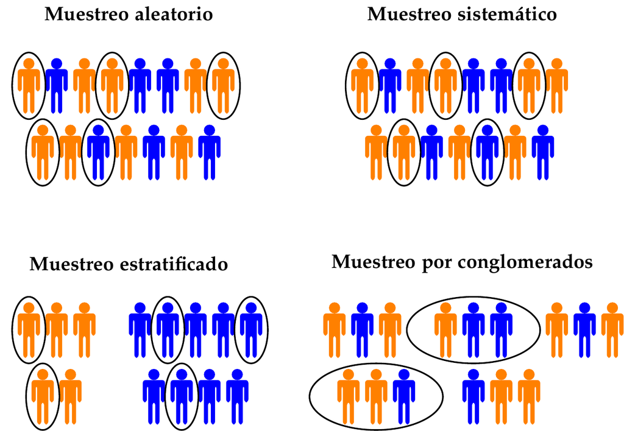

### ¿Pero qué pasa cuando combinamos estratificación y conglomerados ?

**No todos los individuos o viviendas en la población tienen la misma probabilidad final de ser incluidos en la muestra**

Esto pasa porque la selección se hace en varias etapas y con criterios distintos, no como en un azar simple.

# **Ponderadores**

Los también llamados **Factores de expansión** son un peso que asignamos a cada unidad de la muestra que representa a cuántas unidades esa unidad representa

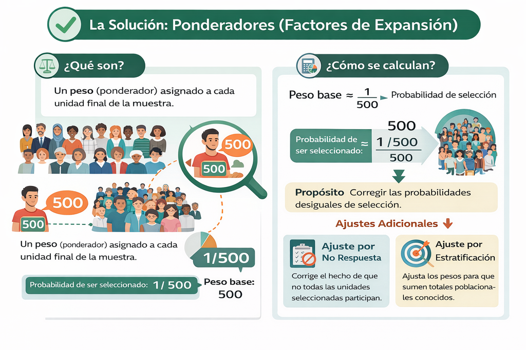

**Ignorar los ponderadores lleva a:**

- Estimaciones Sesgadas
- Conclusiones Erroneas

## Ahora qué debemos hacer con esto?

Al tener muestras complejas debemos calcular nuestros análisis estadisticos con los ponderadores, por lo tanto el codigo que comunmente utilizamos en R (Rbase ) no nos serviran para esto, por lo que tendremos que usar:

# [Survey](https://www.rdocumentation.org/packages/survey/versions/4.5) y [Srvyr](https://cran.r-project.org/web/packages/srvyr/vignettes/srvyr-vs-survey.html)

# **Practiquemos su uso ! :3**

Para hacer esto utilizaremos la Encuesta de Bienestar Social en su versión más reciente que tiene como objetivo medir la calidad de vida de las personas en Chile desde una perspectiva más subjetiva, incorporando dimensiones como la satisfacción con la vida, la felicidad, la salud mental y las relaciones sociales.

**Click para descargar la base [aqui](https://observatorio.ministeriodesarrollosocial.gob.cl/storage/docs/bienestar-social/2023/Base_de_datos_EBS_2023.RData.rar)**

**Click para descargar el libro de codigos [aqui](https://observatorio.ministeriodesarrollosocial.gob.cl/storage/docs/bienestar-social/2023/Libro_de_codigos_EBS_2023.xlsx)**

[figure not shown]

**Como trabajaremos con una base de datos construida con muestreo complejo lo primero que haremos será explorar su libro de datos**

Lo más fundamental es encontrar su Factores de expansión, estratos y conglomerados

**En este caso son:**

| fexp | Factor expansión nacional |
| --- | --- |
| **estrato_ebs** | **Estratos de varianza** |
| **varunit** | **Conglomerados de varianza** |

Ya habiendo encontrado los nombres proseguimos:

## 1. Cargar Paquetes

Lo primero que debemos hacer es preparar nuestro entorno

```r
library(tidyverse)
library(haven)
library(survey)
library(srvyr)
```

## 2. Cargar la base

Al tener la base en formato Rdata debemos usar `load()` que es una función de Rbase y asignamos a un objeto con un nombre simplificado

```r
load("Base de datos EBS 2023.RData")

ebs <- EBS_2023_vp
```

## 3. Explorar la Base

Teniendo la base ya cargada podemos ver como esta construida o resumenes de sus variables claves a utilizar

**En este caso veremos como se comporta los niveles de satisfacción de vida según orientación sexual**

Para ello ocuparemos las siguientes variables:

| tramoebs2 | Tramo de edad |
| --- | --- |
| **os1_recat** | **Orientación Sexual** |
| **a1** | **Qué tan satisfecho(a) o insatisfecho(a) se encuentra con su vida** |
| **sg01** | **Sexo** |

```r
head(ebs)
```

```
# A tibble: 6 × 276
  folio_et_enmascarado id_unico_viv_enmascarado id_hogar id_persona glosa_region
                 <dbl>                    <dbl> <chr>    <chr>      <chr>
1            100170537               5029559728 01       2          Antofagasta
2            100300018               1264296981 01       1          Valparaiso
3            100354319               3987849759 01       1          Coquimbo
4            100370072               3859144699 01       4          Coquimbo
5            100385624               9934790304 01       2          Antofagasta
6            100448717               7945070505 01       3          Metropolita…
# ℹ 271 more variables: glosa_area <chr>, cdf_unificado <chr>, hora_hr <chr>,
#   fexp <dbl>, estrato_ebs <dbl>, varunit <dbl>, l1 <dbl>,
#   tramoebs2 <dbl+lbl>, l1_a <dbl+lbl>, sg01 <dbl+lbl>, sg02 <dbl+lbl>,
#   sg03 <dbl+lbl>, l3_recat <dbl+lbl>, l4 <dbl+lbl>, l5_recat <dbl+lbl>,
#   l6 <dbl+lbl>, l7 <dbl+lbl>, l8 <dbl+lbl>, l9 <dbl+lbl>, l10 <dbl+lbl>,
#   l10_a <dbl+lbl>, l11 <dbl+lbl>, a1 <dbl+lbl>, a2_a <dbl+lbl>,
#   a2_b <dbl+lbl>, a2_c <dbl+lbl>, a2_d <dbl+lbl>, a3 <dbl+lbl>, …
```

```r
summary(as_factor(ebs$tramoebs2))
```

```
 1. 18 a 29 años  2. 30 a 44 años  3. 45 a 59 años  4. 60 A 79 años
            2050             2791             2785             3170
5. 80 años o más
             438
```

```r
summary(as_factor(ebs$os1_recat))
```

```
     No responde          No sabe 1. Gay/ Lesbiana      2. Bisexual
              86               51              133              197
 3. Heterosexual
           10767
```

```r
summary(as_factor(ebs$a1))
```

```
                  No responde                       No sabe
                            2                            12
1. Totalmente insatisfecho(a)            2. Insatisfecho(a)
                          154                          1077
               3. Indiferente              4. Satisfecho(a)
                         1095                          6409
  5. Totalmente satisfecho(a)
                         2485
```

```r
summary(as_factor(ebs$sg01))
```

```
1. Hombre  2. Mujer
     4557      6677
```

**Veamos ahora las variables que identificamos del muestreo complejo :**

```r
summary(ebs$fexp)
```

```
   Min. 1st Qu.  Median    Mean 3rd Qu.    Max.
     37     506     898    1353    1587   13063
```

```r
summary(ebs$estrato_ebs)
```

```
   Min. 1st Qu.  Median    Mean 3rd Qu.    Max.
   1.00    9.00   17.00   16.58   25.00   32.00
```

```r
summary(ebs$varunit)
```

```
   Min. 1st Qu.  Median    Mean 3rd Qu.    Max.
      1    2651    6150    5933    8856   12062
```

Con estas tres variables, R dispondrá de toda la información necesaria para entender la estructura del diseño muestral

**IMPORTANTÍSIMO!!!!!!!!!!!!!!!!!!!!!**

**TODAS LAS RECONFIGURACIONES QUE SE REALICÉN DEBEN SER REALIZADAS ANTES DE DECLARAR EL DISEÑO**

```r
#Borramos Perdidos en Orientación sexual y pasamos a factor
ebs <- ebs%>%
  mutate(os1_recat = ifelse(os1_recat %in% c(-99, -88), NA, os1_recat))

ebs <- ebs%>%
  mutate(a1 = ifelse(a1 %in% c(-99, -88), NA, a1))

ebs <- ebs %>%
  mutate(os1_recat = factor(os1_recat,
    levels = c(1, 2, 3),
    labels = c("Gay/Lesbiana", "Bisexual", "Heterosexual")
  ))
```

## 4. Creando el diseño muestral

**CON SURVEY**

```r
ebs_survey<- svydesign(ids = ~varunit,
                          strata = ~estrato_ebs,
                          weights = ~fexp,
                          data = ebs)
```

**CON SRVYR**

```r
ebs_srvyr <- as_survey_design(ebs,
                              ids = varunit,
                              strata = estrato_ebs,
                              weights = fexp )
```

## 5.Calculos con diseño

**CON SURVEY**

```r
edad_ponderado <- svymean(~tramoebs2, design = ebs_survey, na.rm = TRUE)
satis_ponderado <- svymean(~a1, design = ebs_survey, na.rm = TRUE)
ori_ponderado <- svymean(~os1_recat, design = ebs_survey, na.rm = TRUE)

satis_ponderado
```

```
     mean     SE
a1 3.8895 0.0125
```

```r
edad_ponderado
```

```
            mean    SE
tramoebs2 2.5564 0.015
```

```r
ori_ponderado
```

```
                          mean     SE
os1_recatGay/Lesbiana 0.016556 0.0019
os1_recatBisexual     0.021399 0.0020
os1_recatHeterosexual 0.962045 0.0028
```

**CON SRVYR**

```r
medias_pond<- ebs_srvyr %>%
  summarise( satis_media = survey_mean(a1, na.rm = TRUE, vartype = "ci"),
    edad_media  = survey_mean(tramoebs2,  na.rm = TRUE, vartype = "ci")
  )

medias_pond
```

```
# A tibble: 1 × 6
  satis_media satis_media_low satis_media_upp edad_media edad_media_low
        <dbl>           <dbl>           <dbl>      <dbl>          <dbl>
1        3.89            3.86            3.91       2.56           2.53
# ℹ 1 more variable: edad_media_upp <dbl>
```

**Cómo quedaría sin DMC**

En gran parte de los cálculos nos darían diferencias, ya que estaríamos tratando a la muestra como una de MAS

**EJEMPLO**

```r
mean(ebs$tramoebs2)
```

```
[1] 2.746751
```

```r
mean(ebs$a1)
```

```
[1] NA
```

Mientras que con Muestreo complejo la media de tramos de edad nos da **2.55** sin muestreo complejo la misma media nos da **2.74**

**Por lo tanto para lograr estimaciones correctas es fundamnetal utilizar Diseño muestral complejo en aquellas bases de datos que lo requieran**

## 6. Análisis final

Para finalizar utilizaremos las variables escogidas para ver la satisfacción con la vida según orientación sexual

**CON SURVEY**

```r
svyby(
  ~a1,
  ~os1_recat,
  design = ebs_survey,
  FUN = svymean,
  na.rm = TRUE
)
```

```
                os1_recat       a1         se
Gay/Lesbiana Gay/Lesbiana 3.867465 0.07641154
Bisexual         Bisexual 3.896260 0.07471360
Heterosexual Heterosexual 3.891555 0.01285612
```

**CON SRVYR**

```r
ebs_srvyr %>%
  group_by(os1_recat) %>%
  summarise(
    satis_media = survey_mean(a1, na.rm = TRUE),
    .groups = "drop")
```

```
# A tibble: 4 × 3
  os1_recat    satis_media satis_media_se
  <fct>              <dbl>          <dbl>
1 Gay/Lesbiana        3.87         0.0764
2 Bisexual            3.90         0.0747
3 Heterosexual        3.89         0.0129
4 <NA>                3.76         0.124
```

### Análisis de significancia

Para evaluar si las diferencias observadas en la satisfacción con la vida según orientación sexual son estadísticamente significativas, podemos estimar un modelo de regresión considerando el diseño muestral complejo.

```r
modelo <- svyglm(
  as.numeric(a1) ~ os1_recat,
  design = ebs_survey)
summary(modelo)
```

```
Call:
svyglm(formula = as.numeric(a1) ~ os1_recat, design = ebs_survey)

Survey design:
svydesign(ids = ~varunit, strata = ~estrato_ebs, weights = ~fexp,
    data = ebs)

Coefficients:
                      Estimate Std. Error t value Pr(>|t|)
(Intercept)            3.86746    0.07641  50.614   <2e-16 ***
os1_recatBisexual      0.02880    0.10690   0.269    0.788
os1_recatHeterosexual  0.02409    0.07725   0.312    0.755
---
Signif. codes:  0 '***' 0.001 '**' 0.01 '*' 0.05 '.' 0.1 ' ' 1

(Dispersion parameter for gaussian family taken to be 0.8272174)

Number of Fisher Scoring iterations: 2
```

# **OTROS**

Otras funciones que les pueden servir para proximos trabajos con diseño muestral complejo

## SRVYR

| Código | ¿Para qué sirve? | Ejemplo |
| --- | --- | --- |
| `as_survey_design()` | Crear el diseño muestral | `as_survey_design(data, ids, strata, weights)` |
| `group_by()` | Agrupar datos | `group_by(sexo)` |
| `summarise()` | Calcular estadísticas | `summarise(media = survey_mean(x))` |
| `survey_mean()` | Media ponderada | `survey_mean(ingreso)` |
| `survey_total()` | Total poblacional estimado | `survey_total(ingreso)` |
| `survey_prop()` | Proporciones ponderadas | `survey_prop()` |
| `survey_ratio()` | Razones entre variables | `survey_ratio(x, y)` |
| `survey_quantile()` | Percentiles ponderados | `survey_quantile(x, 0.5)` |
| `survey_var()` | Varianza | `survey_var(x)` |
| `survey_sd()` | Desviación estándar | `survey_sd(x)` |
| `survey_median()` | Mediana | `survey_median(x)` |

#### Funciones mas avanzadas

Para regresiones con muestreo complejo, **`srvyr` no tiene una función propia**, sino que usa las de `survey` (principalmente `svyglm()`). Pero puedes trabajar desde el objeto `srvyr` sin problema.

## SURVEY

| Código | ¿Para qué sirve? | Ejemplo |
| --- | --- | --- |
| `svydesign()` | Crear el diseño muestral | `svydesign(ids=~varunit, strata=~estrato, weights=~fexp, data=data)` |
| `svymean()` | Media ponderada | `svymean(~ingreso, design)` |
| `svytotal()` | Total poblacional | `svytotal(~ingreso, design)` |
| `svyby()` | Calcular por grupos | `svyby(~x, ~grupo, design, svymean)` |
| `svyprop()` | Proporciones (con tabla) | `svymean(~factor(x), design)` |
| `svyquantile()` | Percentiles | `svyquantile(~x, design, 0.5)` |
| `svyvar()` | Varianza | `svyvar(~x, design)` |
| `svytable()` | Tablas de frecuencia ponderadas | `svytable(~sexo, design)` |

#### **Funciones más Avanzadas**

| Código | ¿Para qué sirve? |
| --- | --- |
| `svyglm()` | Regresión (lineal o logística) |
| `svychisq()` | Test chi-cuadrado con diseño complejo |
| `svyttest()` | Test de medias (t-test) |

El objetivo de esta actividad es aplicar el uso de ponderadores y el diseño muestral complejo.

## Actividad (10 minutos)

El objetivo de esta actividad es aplicar el uso de ponderadores y el diseño muestral complejo.

### Instrucciones

Utilizando la base de datos EBS y el objeto `ebs_srvyr`, responde lo siguiente:

1. Calcular la **media de satisfacción con la vida (`a1`) según sexo (`sg01`)** utilizando `srvyr`.
2. Calcular la **proporción de personas satisfechas** (categorías 4 y 5 de `a1`) según tramo de edad (`tramoebs2`).
3. Responder brevemente:
   - ¿Qué grupo presenta mayor nivel de satisfacción?
   - ¿Por qué es importante usar ponderadores en este análisis?

**Ayuda (si te quedas pegado)**

- Usa `group_by()` y `summarise()`
- Usa `survey_mean()` o `survey_prop()`
- Recuerda usar `na.rm = TRUE`

**Opcional (si te sobra tiempo)**

Realiza el mismo cálculo de la media **sin diseño muestral** (`mean()`) y compara los resultados.

**¿Observas diferencias?**

## **Autoría y fuentes**

Este material fue elaborado por **Francisca Hernández** (francisca.hernandez_c@mail.udp.cl), utilizando desarrollo propio en base a los contenidos del curso. Asimismo, se incorporaron elementos provenientes de las clases del profesor **Gabriel Sotomayor** y recursos complementarios disponibles en internet.